# Prediction Assignment - Week 4 ML

Tony O’Donoghue

8th June 2016

# Introduction

Human Activity Recognition has emerged as an important research area in recent years. With devices such as *Fitbit*, *Nike FuelBand*, and *Jawbone Up* it is now possible to collect inexpensively a large amount of data about personal activity. For this assignmnet data was collected from six young people who were asked to perform one set of 10 repetitions of the Unilateral Dumbbell Biceps Curl in five different fashions: exactly according to the specification (Class A), throwing the elbows to the front (Class B), lifting the dumbbell only halfway (Class C), lowering the dumbbell only halfway (Class D) and throwing the hips to the front (Class E). Measurements were taken form all 6 participants from accelerometers attached on the belt, forearm, arm, and dumbell.

## Data Sources

- Training Data for this assign ment is available at https://d396qusza40orc.cloudfront.net/predmachlearn/pml-training.csv
- Test Data for this assignment is available at https://d396qusza40orc.cloudfront.net/predmachlearn/pml-testing.csv

## Objective

Generate a model or models from the predictors in the training dataset which can predict the **classe** variable. The selected final model will then be used to predict using the test data.

## Data Loading & Feature Extraction

```r
#Load Libraries
library(e1071)
library(lattice)
library(ggplot2)
library(caret)
library(fields)
library(knitr)
```

```r
#Download Files
setwd("C:/MyProjects/Coursera_R/Week4Assignment/")

trainFileUrl <- "https://d396qusza40orc.cloudfront.net/predmachlearn/pml-training.csv"
download.file(trainFileUrl,destfile = "./pml-training.csv")

testFileUrl <- "https://d396qusza40orc.cloudfront.net/predmachlearn/pml-testing.csv"
download.file(testFileUrl,destfile = "./pml-testing.csv")
```

```r
#Load Data Frames
training<- read.csv("pml-training.csv", na.strings= c("", "NA", "#DIV/0!"))
finalTesting<- read.csv("pml-testing.csv", na.strings= c("", "NA", "#DIV/0!"))
```

We will use **60%** of the training data for actual training and **40%** for model testing and evaluation.

```r
set.seed(1234)
inTrain <- createDataPartition(y=training$classe, p=0.6, list=FALSE)
trainingForBuild <- training[inTrain, ]
testingForBuild <- training[-inTrain, ]
```

First seven columns only contains time-stamp, first name, and sequence related data which are not actual movement measurements and are therefore not required.

```r
# Remove first 7 columns
trainingForBuild <- trainingForBuild[, -(1:7)]
```

The “near zero-variance predictors” can cause numerical problems during resampling for some models. The following criteria defines these values:  
1. the percentage of unique values is less than 20% and  
2. the ratio of the most frequent to the second most frequent value is greater than 20.  
Also, remove columns with little or no data (NA greater than 49%).  
Use remaining columns for training and testing.

```r
# Remove near zero variance features
nzvcol <- nearZeroVar(trainingForBuild)
trainingForBuild <- trainingForBuild[, -nzvcol]

# Remove Cols with little or no data
trainColStats<-t(stats(trainingForBuild))
rowCount <- dim(trainingForBuild)[1]

#classe has NA from stats but do not exclude that
colsToRemove<-apply(trainColStats, 1,
               function(currow)
                {

                (currow["missing values"]/rowCount > 0.49) &&      !(is.na(currow))
                })


trainingForBuild<-trainingForBuild[!colsToRemove]

testingForBuild<-testingForBuild[,names(trainingForBuild)]
```

## Final Features

```r
dim(trainingForBuild)
```

```
## [1] 11776    53
```

```r
dim(testingForBuild)
```

```
## [1] 7846   53
```

## Random Forest Model

One big advantage of Random Forest is that they do not expect linear features and the features do not have to interact linearly.Random forests builds large collection of de-correlated trees and then averages them.

**Cross Validation**

Random Forest model has a tuning parameter *mtry* - the number of randomly selected predictors used for each node split. Cross-validation is used to automatically pick this parameter. For now have limited the number of trees to 100 and set number of folds to 5.

```r
set.seed(1234)

system.time(fitRf <- train(classe ~ ., data=trainingForBuild,  method= "rf",ntree = 100, trControl = trainControl(method ="cv", number = 5)))
```

```
##    user  system elapsed
##  156.88    0.91  158.70
```

```r
#Can plot CV error against mtry using:
#plot(fitRf)
fitRf$finalModel
```

```
##
## Call:
##  randomForest(x = x, y = y, ntree = 100, mtry = param$mtry)
##                Type of random forest: classification
##                      Number of trees: 100
## No. of variables tried at each split: 27
##
##         OOB estimate of  error rate: 1.03%
## Confusion matrix:
##      A    B    C    D    E class.error
## A 3337    8    2    0    1 0.003285544
## B   23 2249    7    0    0 0.013163668
## C    0   16 2025   13    0 0.014118793
## D    0    0   29 1899    2 0.016062176
## E    0    0    9   11 2145 0.009237875
```

Evaluation of Random Forest against test data:

```r
preditFitRf <- predict(fitRf, newdata = testingForBuild)
conRf <- confusionMatrix(preditFitRf, testingForBuild$classe)
RfAccuracy <-conRf$overall["Accuracy"]

misClassification = function(v, p) {
    sum(p != v)/length(v)
}
classErrorRate <- misClassification (testingForBuild$classe, preditFitRf)

conRf
```

```
## Confusion Matrix and Statistics
##
##           Reference
## Prediction    A    B    C    D    E
##          A 2230   24    0    0    0
##          B    1 1488   13    1    1
##          C    1    6 1347   21    2
##          D    0    0    8 1262    3
##          E    0    0    0    2 1436
##
## Overall Statistics
##
##                Accuracy : 0.9894
##                  95% CI : (0.9869, 0.9916)
##     No Information Rate : 0.2845
##     P-Value [Acc > NIR] : < 2.2e-16
##
##                   Kappa : 0.9866
##  Mcnemar's Test P-Value : NA
##
## Statistics by Class:
##
##                      Class: A Class: B Class: C Class: D Class: E
## Sensitivity            0.9991   0.9802   0.9846   0.9813   0.9958
## Specificity            0.9957   0.9975   0.9954   0.9983   0.9997
## Pos Pred Value         0.9894   0.9894   0.9782   0.9914   0.9986
## Neg Pred Value         0.9996   0.9953   0.9968   0.9963   0.9991
## Prevalence             0.2845   0.1935   0.1744   0.1639   0.1838
## Detection Rate         0.2842   0.1897   0.1717   0.1608   0.1830
## Detection Prevalence   0.2873   0.1917   0.1755   0.1622   0.1833
## Balanced Accuracy      0.9974   0.9889   0.9900   0.9898   0.9978
```

## Random Forest Out Of Sample Error Rate

The accuracy of the Random Forest is 0.9894214. Actual misclassification error rate on test data is 1.0578639%.  
The graph below shows how the training error was reduced as the number of trees grew.

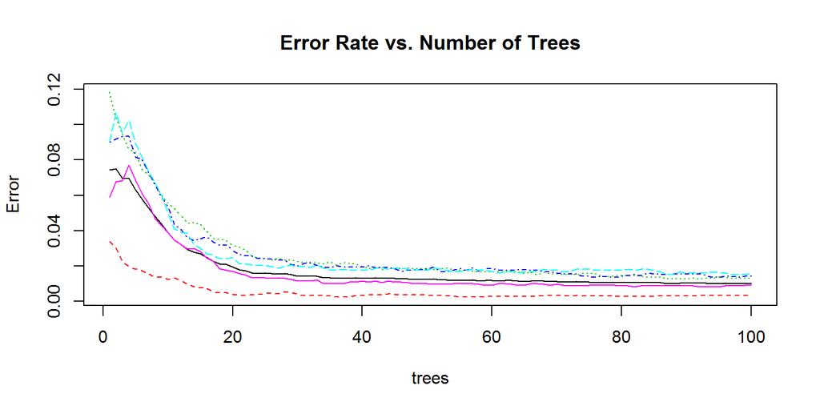

```r
plot(fitRf$finalMode, main="Error Rate vs. Number of Trees")
```

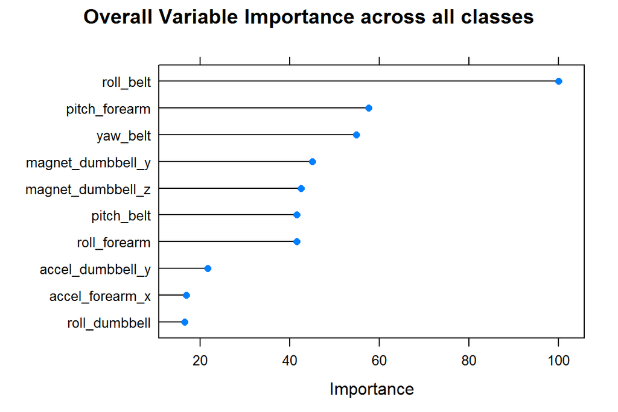

```r
#if you set importance=T in the training set can get more detaild plot of importance.
plot(varImp(fitRf), top = 10, main="Overall Variable Importance across all classes")
```

## Stochastic Gradient Boosting

Boosting trees are grown sequentially. Each tree is grown using information from the previously grown tree. Each new tree is fitted using the residuals of the model. There is a parameter d which sets each tree terminal nodes and a shrinkage parameter lambda.

**Cross Validation**

```r
set.seed(1234)
myTuneGrid <- expand.grid(n.trees = seq(50,250,50),interaction.depth = 1:3,shrinkage = 0.1, n.minobsinnode = 10)
system.time(fitGbm <- train(classe ~ ., data=trainingForBuild, method= "gbm", verbose = F, tuneGrid=myTuneGrid, trControl = trainControl(method ="cv", number = 5)))
```

```
##    user  system elapsed
##  553.72    0.83  557.26
```

```r
fitGbm
```

```
## Stochastic Gradient Boosting
##
## 11776 samples
##    52 predictor
##     5 classes: 'A', 'B', 'C', 'D', 'E'
##
## No pre-processing
## Resampling: Cross-Validated (5 fold)
## Summary of sample sizes: 9420, 9420, 9420, 9422, 9422
## Resampling results across tuning parameters:
##
##   interaction.depth  n.trees  Accuracy   Kappa
##   1                   50      0.7486404  0.6815979
##   1                  100      0.8180172  0.7697830
##   1                  150      0.8517300  0.8124756
##   1                  200      0.8724500  0.8386295
##   1                  250      0.8883302  0.8586984
##   2                   50      0.8504551  0.8106080
##   2                  100      0.9027656  0.8769737
##   2                  150      0.9301109  0.9115774
##   2                  200      0.9458204  0.9314522
##   2                  250      0.9559260  0.9442458
##   3                   50      0.8960588  0.8684442
##   3                  100      0.9404715  0.9246813
##   3                  150      0.9599179  0.9492961
##   3                  200      0.9696833  0.9616545
##   3                  250      0.9759672  0.9696017
##
## Tuning parameter 'shrinkage' was held constant at a value of 0.1
##
## Tuning parameter 'n.minobsinnode' was held constant at a value of 10
## Accuracy was used to select the optimal model using  the largest value.
## The final values used for the model were n.trees = 250,
##  interaction.depth = 3, shrinkage = 0.1 and n.minobsinnode = 10.
```

Cross vaidation results picked n.trees = 250 and interaction.depth = 3. Held constant were Shrinkage = 0.1 and n.minobsinnode = 10. Here a *tuneGrid* object is created with max tree of 250. The Boosting Model gets more accurate as he number of trees increase.

Evaluation Boosting Model against test data:

```r
preditFitGbm <- predict(fitGbm, newdata = testingForBuild)
conGbm <- confusionMatrix(preditFitGbm, testingForBuild$classe)
GbmAccuracy <-conGbm$overall["Accuracy"]

classErrorRateGbm <- misClassification (testingForBuild$classe, preditFitGbm)

conGbm
```

```
## Confusion Matrix and Statistics
##
##           Reference
## Prediction    A    B    C    D    E
##          A 2218   31    0    0    0
##          B   10 1457   37    2   15
##          C    3   28 1315   26    5
##          D    1    0   14 1255   10
##          E    0    2    2    3 1412
##
## Overall Statistics
##
##                Accuracy : 0.9759
##                  95% CI : (0.9723, 0.9792)
##     No Information Rate : 0.2845
##     P-Value [Acc > NIR] : < 2.2e-16
##
##                   Kappa : 0.9695
##  Mcnemar's Test P-Value : NA
##
## Statistics by Class:
##
##                      Class: A Class: B Class: C Class: D Class: E
## Sensitivity            0.9937   0.9598   0.9613   0.9759   0.9792
## Specificity            0.9945   0.9899   0.9904   0.9962   0.9989
## Pos Pred Value         0.9862   0.9579   0.9550   0.9805   0.9951
## Neg Pred Value         0.9975   0.9904   0.9918   0.9953   0.9953
## Prevalence             0.2845   0.1935   0.1744   0.1639   0.1838
## Detection Rate         0.2827   0.1857   0.1676   0.1600   0.1800
## Detection Prevalence   0.2866   0.1939   0.1755   0.1631   0.1809
## Balanced Accuracy      0.9941   0.9749   0.9758   0.9860   0.9891
```

## Boosting Out Of Sample Error Rate

The accuracy of the Boosting Model is 0.9759113. Actual misclassification error rate on test data is 2.4088708%.

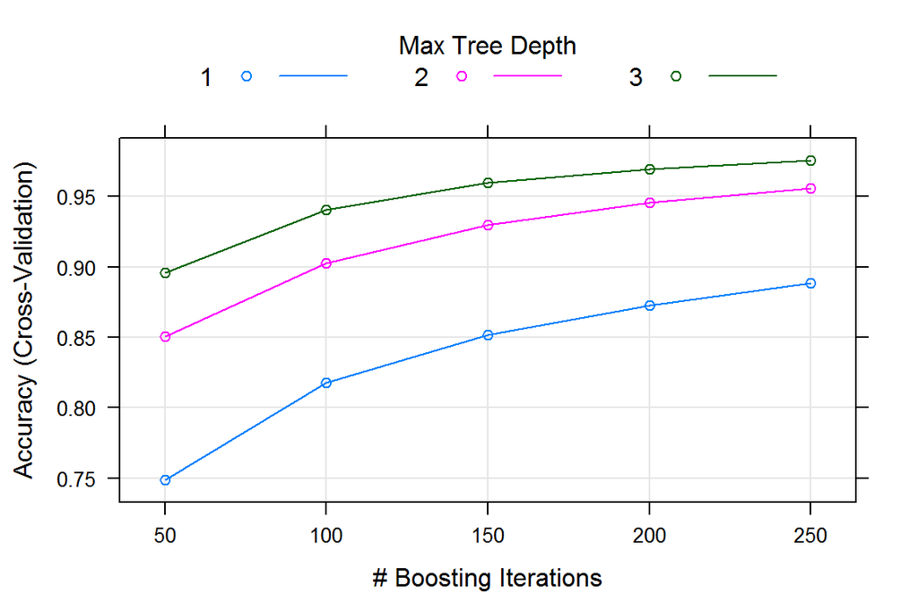

```r
plot(fitGbm)
```

```r
fitGbm$finalModel
```

```
## A gradient boosted model with multinomial loss function.
## 250 iterations were performed.
## There were 52 predictors of which 48 had non-zero influence.
```

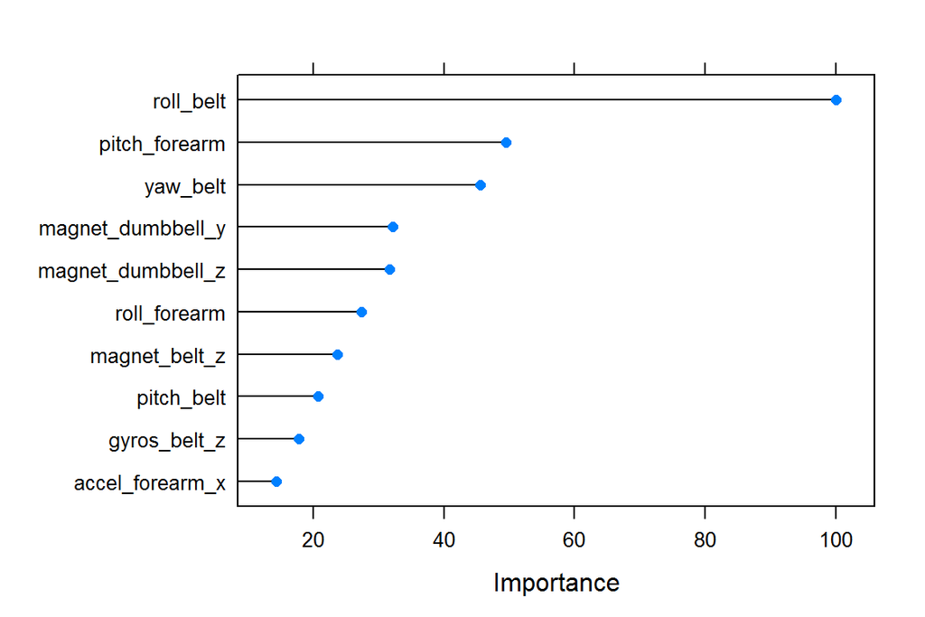

```r
plot(varImp(fitGbm), top = 10)
```

## Quadratic Discriminant Analysis

QDA has no tuning parameters, so no cross-validtion will be carried out for tuning purposes. By default Bootstraping is used for resampling and gives an estimated Accuracy of 0.8920098.

```r
set.seed(1234)
system.time(fitQda <- train(classe ~ ., data=trainingForBuild, method= "qda"))
```

```
##    user  system elapsed
##    8.93    0.88    9.81
```

```r
fitQda
```

```
## Quadratic Discriminant Analysis
##
## 11776 samples
##    52 predictor
##     5 classes: 'A', 'B', 'C', 'D', 'E'
##
## No pre-processing
## Resampling: Bootstrapped (25 reps)
## Summary of sample sizes: 11776, 11776, 11776, 11776, 11776, 11776, ...
## Resampling results:
##
##   Accuracy   Kappa
##   0.8920098  0.863578
##
##
```

Evaluation QDA Model against test data:

```r
preditFitQda <- predict(fitQda, newdata = testingForBuild)
conQda <- confusionMatrix(preditFitQda, testingForBuild$classe)
QdaAccuracy <-conQda$overall["Accuracy"]

classErrorRateQda <- misClassification (testingForBuild$classe, preditFitQda)

conQda
```

```
## Confusion Matrix and Statistics
##
##           Reference
## Prediction    A    B    C    D    E
##          A 2052   72    2    0    0
##          B  101 1263   77    7   49
##          C   43  166 1270  170   63
##          D   30    4   12 1100   30
##          E    6   13    7    9 1300
##
## Overall Statistics
##
##                Accuracy : 0.8903
##                  95% CI : (0.8831, 0.8971)
##     No Information Rate : 0.2845
##     P-Value [Acc > NIR] : < 2.2e-16
##
##                   Kappa : 0.8615
##  Mcnemar's Test P-Value : < 2.2e-16
##
## Statistics by Class:
##
##                      Class: A Class: B Class: C Class: D Class: E
## Sensitivity            0.9194   0.8320   0.9284   0.8554   0.9015
## Specificity            0.9868   0.9630   0.9318   0.9884   0.9945
## Pos Pred Value         0.9652   0.8437   0.7418   0.9354   0.9738
## Neg Pred Value         0.9685   0.9598   0.9840   0.9721   0.9782
## Prevalence             0.2845   0.1935   0.1744   0.1639   0.1838
## Detection Rate         0.2615   0.1610   0.1619   0.1402   0.1657
## Detection Prevalence   0.2710   0.1908   0.2182   0.1499   0.1702
## Balanced Accuracy      0.9531   0.8975   0.9301   0.9219   0.9480
```

## QDA Out Of Sample Error Rate

The accuracy of the Quadratic Discriminant Analysis Model is 0.8902626. Actual misclassification error rate on test data is 10.9737446%.

# Conclusion

The Random Forest model is the most accurate and will use it for final test set. For this assignment the Random Forest model was well suited and it produced excellent results on the training/validation and test sets.  
- It gives estimates of what variables are important in the classification.  
- Gives good perfromance on a large dataset with many predictors.  
- with caret and cross-validation can automtically select tuning parameters.

For this exercise Boosting could potentially be as accurate but the interaction depth and number of trees would need to be increased, and thus would take much longer to train.

Quadratic Discriminant Analysis was the least accurate but was by far the quickest to train.

```r
preditFitRfFinal <- predict(fitRf, newdata = finalTesting)
preditFitGbmFinal <- predict(fitGbm, newdata = finalTesting)
preditFitQdaFinal <- predict(fitQda, newdata = finalTesting)

preditFitRfFinal
```

```
##  [1] B A B A A E D B A A B C B A E E A B B B
## Levels: A B C D E
```

```r
preditFitGbmFinal
```

```
##  [1] B A B A A E D B A A B C B A E E A B B B
## Levels: A B C D E
```

```r
preditFitQdaFinal
```

```
##  [1] A A B A A E D B A A B C B A E E A B B B
## Levels: A B C D E
```